# Lesson 4

### Scatterplots

Notes: Use a scatterplot to examine the relationship between two continuous variables.

Load the data and plot with qplot.

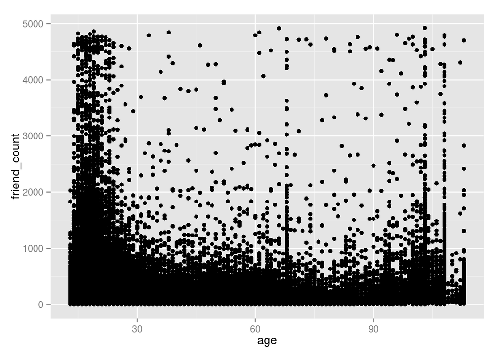

```r
library(ggplot2)
pf = read.csv('pseudo_facebook.tsv', sep='\t')
qplot(x=age, y=friend_count, data=pf)
```

Let’s plot the same thing with ggplot.

### ggplot Syntax

Notes:

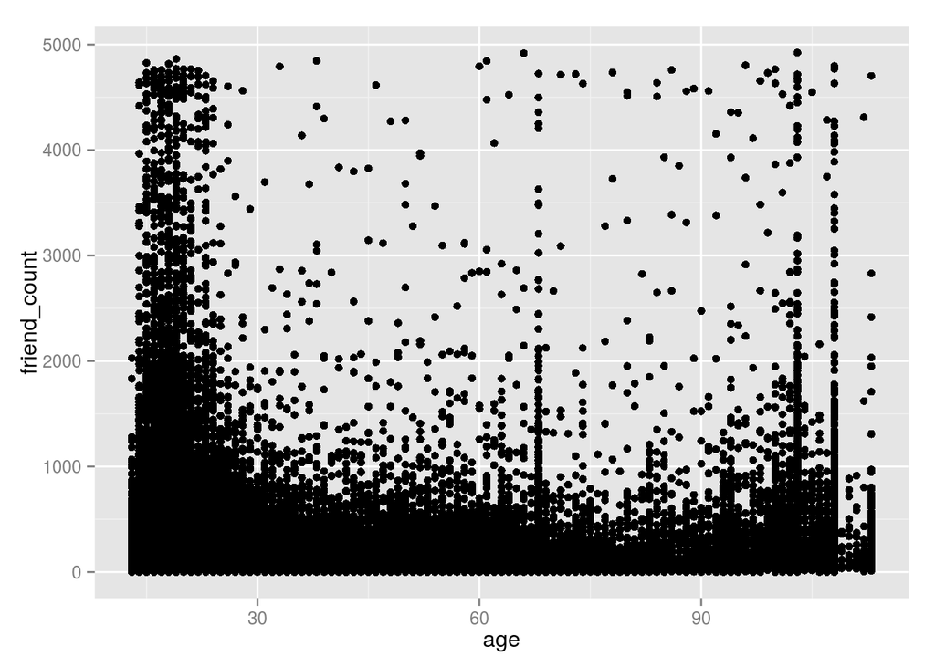

```r
ggplot(aes(x=age, y=friend_count), data = pf) +
  geom_point()
```

```r
summary(pf$age)
```

```
##    Min. 1st Qu.  Median    Mean 3rd Qu.    Max.
##   13.00   20.00   28.00   37.28   50.00  113.00
```

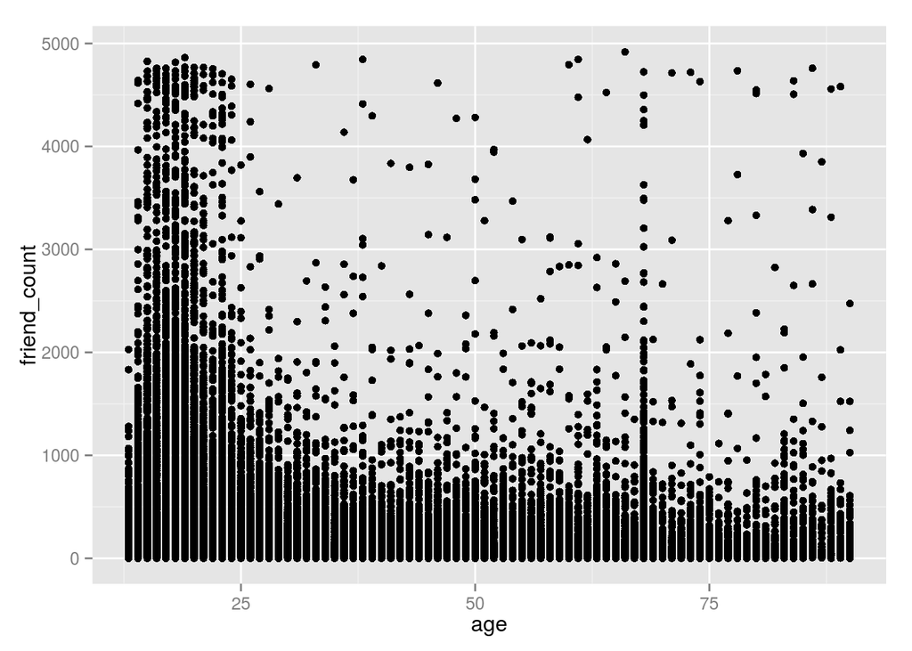

```r
ggplot(aes(x=age, y=friend_count), data = pf) +
  geom_point() +
  xlim(13, 90)
```

### Overplotting

Notes: Set the alpha parameter to avoid overplotting or geom_jitter.

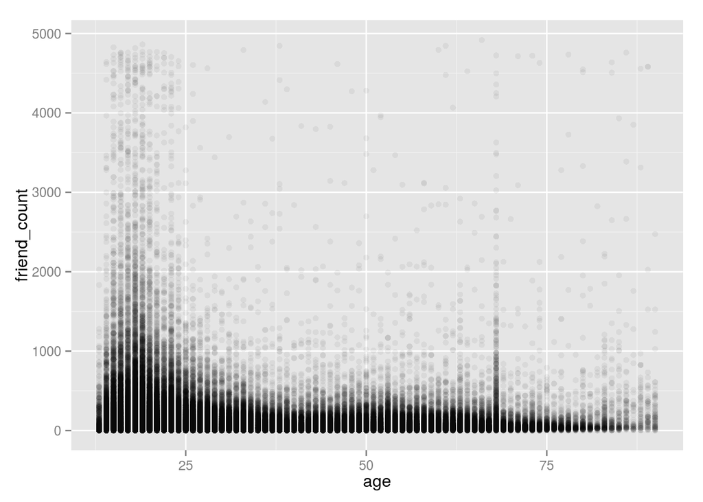

```r
ggplot(aes(x=age, y=friend_count), data = pf) +
  geom_point(alpha=1/20) +
  xlim(13, 90)
```

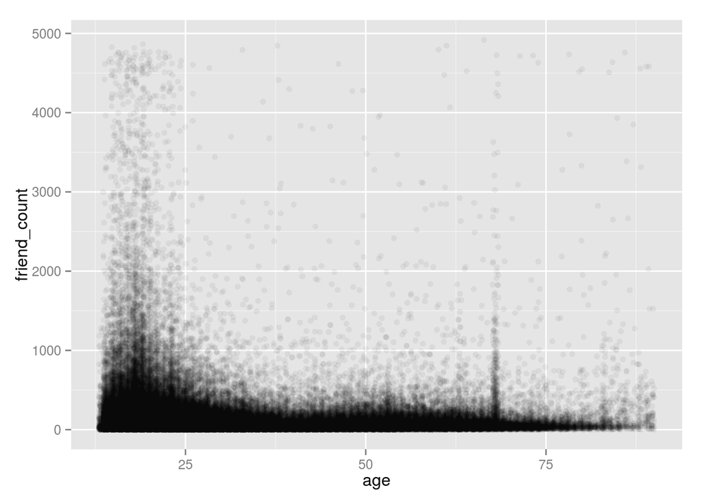

```r
ggplot(aes(x=age, y=friend_count), data = pf) +
  geom_jitter(alpha=1/20) +
  xlim(13, 90)
```

### Coord_trans()

Notes:

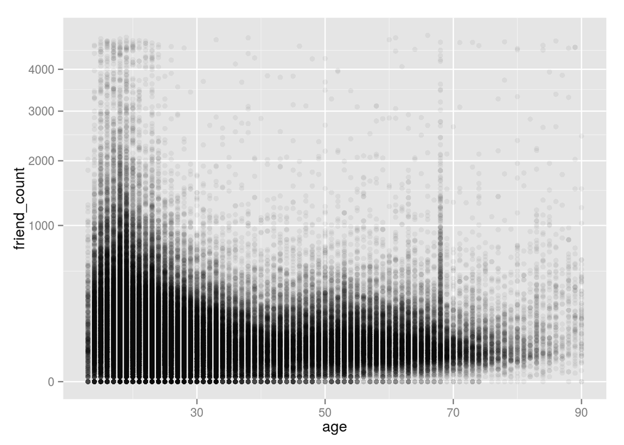

```r
ggplot(aes(x=age, y=friend_count), data = pf) +
  geom_point(alpha=1/20) +
  xlim(13, 90) +
  coord_trans(y='sqrt')
```

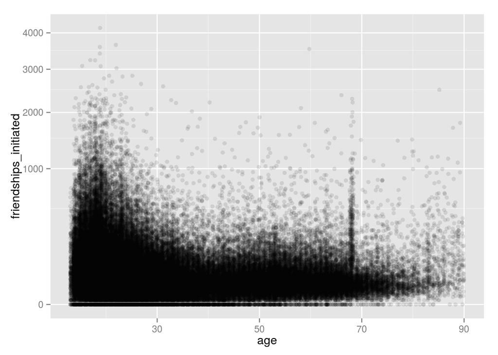

```r
ggplot(aes(x=age, y=friendships_initiated), data=pf) +
  geom_point(alpha = 1/10, position = position_jitter(h=0)) +
  xlim(13,90) +
  coord_trans(y="sqrt")
```

### Alpha and Jitter

Notes:

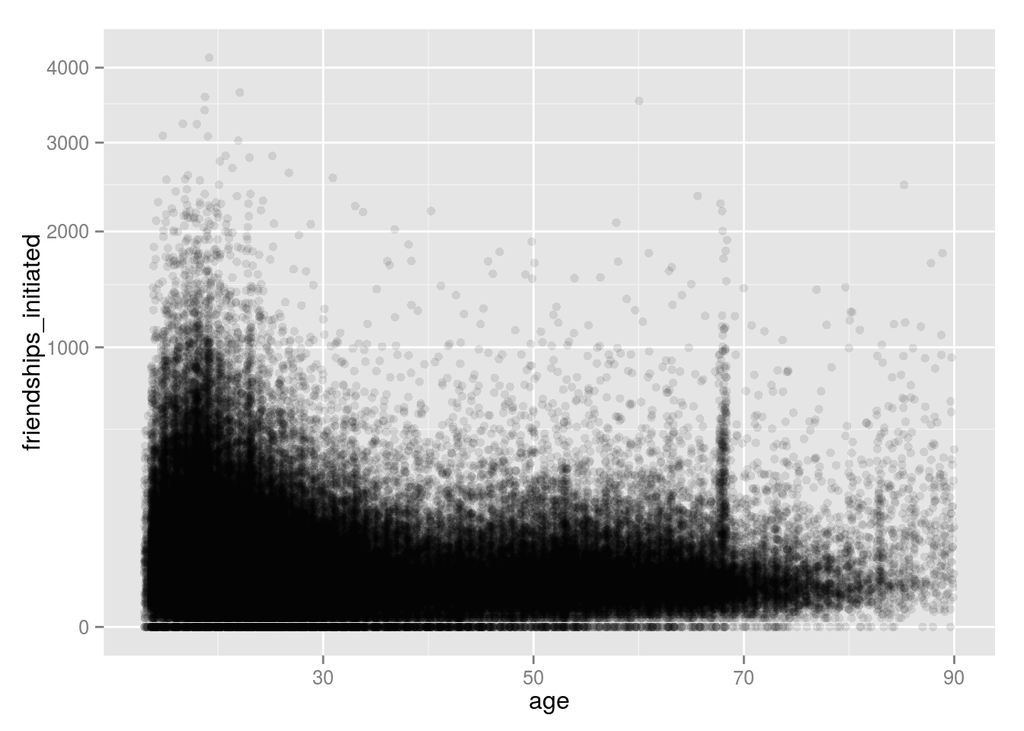

```r
ggplot(aes(x=age, y=friendships_initiated), data=pf) +
  geom_point(alpha = 1/10, position = position_jitter(h=0)) +
  xlim(13,90) +
  coord_trans(y="sqrt")
```

### Conditional Means

Notes:

```r
#install.packages('dplyr')
library(dplyr)
age_groups = group_by(pf, age)
pf.fc_by_age = summarise(age_groups,
          friend_count_mean = mean(friend_count),
          friend_count_median = median(friend_count),
          n = n())

head(pf.fc_by_age)
```

```
## Source: local data frame [6 x 4]
##
##   age friend_count_mean friend_count_median    n
## 1  13          164.7500                74.0  484
## 2  14          251.3901               132.0 1925
## 3  15          347.6921               161.0 2618
## 4  16          351.9371               171.5 3086
## 5  17          350.3006               156.0 3283
## 6  18          331.1663               162.0 5196
```

```r
# to reverse the order
# pf.fc_by_age = arrange(pf.fc_by_age, age)

# Alternate Terminology:
pf.fc_by_age = pf %>%
  group_by(age) %>%
  summarise(friend_count_mean = mean(friend_count),
            friend_count_median = median(friend_count),
            n = n())
```

Create your plot!

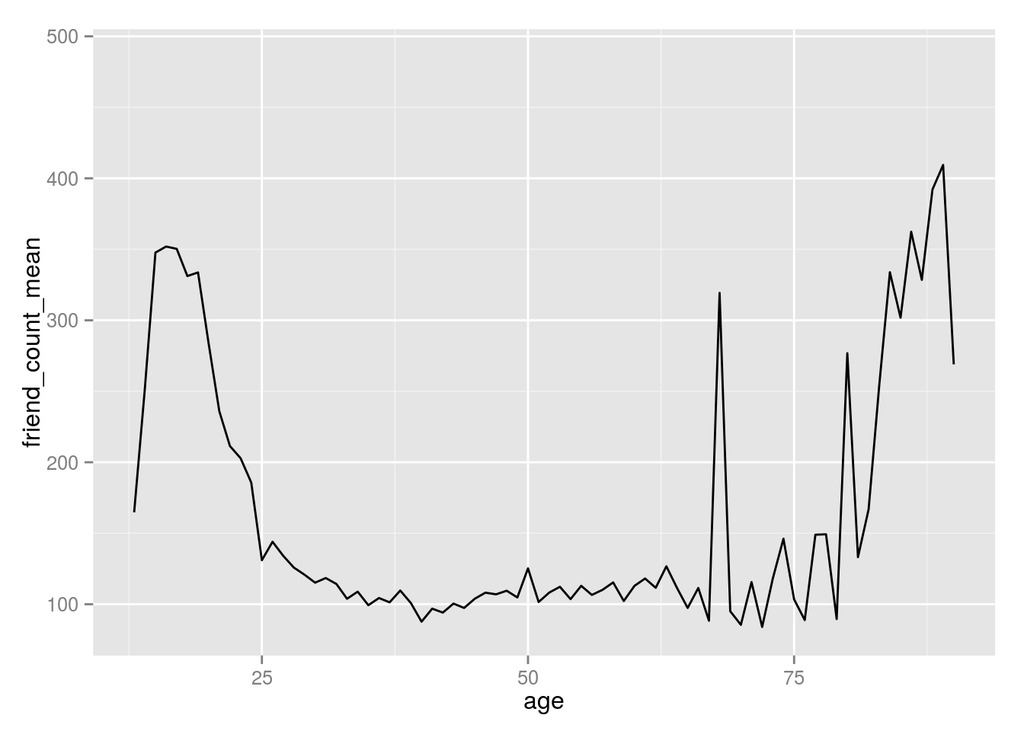

```r
ggplot(aes(x=age, y=friend_count_mean), data = pf.fc_by_age) +
  geom_line() +
  xlim(13, 90)
```

### Overlaying Summaries with Raw Data

Notes:

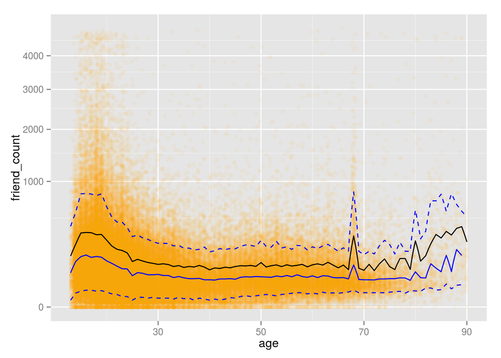

```r
ggplot(aes(x=age, y=friend_count), data=pf) +
  xlim(13,90) +
  geom_point(alpha = 0.05,
             position = position_jitter(h=0),
             color = 'orange') +
  coord_trans(y="sqrt") +
  geom_line(stat='summary', fun.y=mean) +
  geom_line(stat='summary', fun.y= quantile, probs = .1,
            linetype=2, color='blue') +
  geom_line(stat='summary', fun.y=quantile, probs = .9,
            linetype=2, color='blue') +
  geom_line(stat='summary', fun.y=quantile, probs = .5,
            color='blue')
```

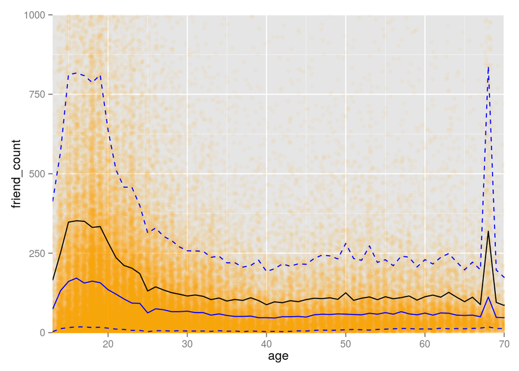

```r
# Zoom in with a coord_cartesian layer.
ggplot(aes(x=age, y=friend_count), data=pf) +
  coord_cartesian(xlim=c(13,70), ylim=c(0,1000)) +
  geom_point(alpha = 0.05,
             position = position_jitter(h=0),
             color = 'orange') +
  geom_line(stat='summary', fun.y=mean) +
  geom_line(stat='summary', fun.y= quantile, probs = .1,
            linetype=2, color='blue') +
  geom_line(stat='summary', fun.y=quantile, probs = .9,
            linetype=2, color='blue') +
  geom_line(stat='summary', fun.y=quantile, probs = .5,
            color='blue')
```

#### What are some of your observations of the plot?

Response: It is very rare to have more than 1000 friends even for younger users. ***

### Correlation

Notes: Correlation > 0.3 or < -0.3 is meaningful, but small. Correlation > 0.5 or < -0.5 is moderate. Correlation > 0.7 or < -0.7 is large.

```r
cor(pf$age, pf$friend_count)
```

```
## [1] -0.02740737
```

```r
cor.test(pf$age, pf$friend_count, method = 'pearson')
```

```
##
##  Pearson's product-moment correlation
##
## data:  pf$age and pf$friend_count
## t = -8.6268, df = 99001, p-value < 2.2e-16
## alternative hypothesis: true correlation is not equal to 0
## 95 percent confidence interval:
##  -0.03363072 -0.02118189
## sample estimates:
##         cor
## -0.02740737
```

```r
with(pf, cor.test(age, friend_count, method = 'pearson'))
```

```
##
##  Pearson's product-moment correlation
##
## data:  age and friend_count
## t = -8.6268, df = 99001, p-value < 2.2e-16
## alternative hypothesis: true correlation is not equal to 0
## 95 percent confidence interval:
##  -0.03363072 -0.02118189
## sample estimates:
##         cor
## -0.02740737
```

Look up the documentation for the cor.test function.

What’s the correlation between age and friend count? Round to three decimal places. Response: -0.027 ***

### Correlation on Subsets

Notes:

```r
with(subset(pf, age <= 70) , cor.test(age, friend_count))
```

```
##
##  Pearson's product-moment correlation
##
## data:  age and friend_count
## t = -52.5923, df = 91029, p-value < 2.2e-16
## alternative hypothesis: true correlation is not equal to 0
## 95 percent confidence interval:
##  -0.1780220 -0.1654129
## sample estimates:
##        cor
## -0.1717245
```

```r
with(subset(pf, age <= 70) , cor.test(age, friend_count,
                                      method = 'spearman'))
```

```
##
##  Spearman's rank correlation rho
##
## data:  age and friend_count
## S = 1.5782e+14, p-value < 2.2e-16
## alternative hypothesis: true rho is not equal to 0
## sample estimates:
##        rho
## -0.2552934
```

## Create Scatterplots

Notes:

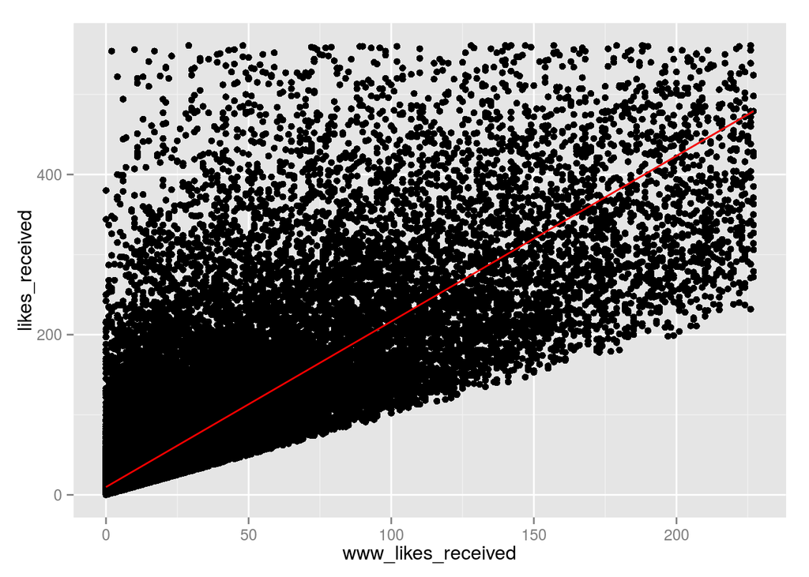

```r
ggplot(aes(x = www_likes_received, y = likes_received), data = pf) +
  geom_point() +
  xlim(0, quantile(pf$www_likes_received, 0.95)) +
  ylim(0, quantile(pf$likes_received, 0.95)) +
  geom_smooth(method = 'lm', color='red')
```

### Strong Correlations

Notes: The correlation coefficient is invariant under a linear transformation of either X or Y, and the slope of the regression line when both X and Y have been transformed to z-scores is the correlation coefficient.

It’s important to note that we may not always be interested in the bulk of the data. Sometimes, the outliers ARE of interest, and it’s important that we understand their values and why they appear in the data set.

What’s the correlation betwen the two variables? Include the top 5% of values for the variable in the calculation and round to 3 decimal places.

```r
cor.test(pf$www_likes_received, pf$likes_received, method = 'pearson')
```

```
##
##  Pearson's product-moment correlation
##
## data:  pf$www_likes_received and pf$likes_received
## t = 937.1035, df = 99001, p-value < 2.2e-16
## alternative hypothesis: true correlation is not equal to 0
## 95 percent confidence interval:
##  0.9473553 0.9486176
## sample estimates:
##       cor
## 0.9479902
```

```r
#install.packages('alr3')
library(alr3)
data(Mitchell)
```

Create your plot!

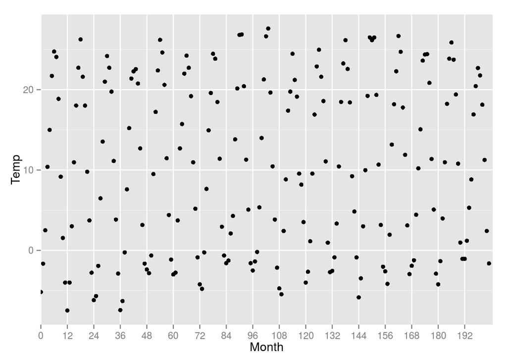

```r
ggplot(aes(x = Month, y = Temp), data = Mitchell) +
  geom_point() +
  scale_x_discrete(breaks = seq(0, 203, 12))
```

```r
cor.test(Mitchell$Month, Mitchell$Temp, method = 'pearson')
```

```
##
##  Pearson's product-moment correlation
##
## data:  Mitchell$Month and Mitchell$Temp
## t = 0.8182, df = 202, p-value = 0.4142
## alternative hypothesis: true correlation is not equal to 0
## 95 percent confidence interval:
##  -0.08053637  0.19331562
## sample estimates:
##        cor
## 0.05747063
```

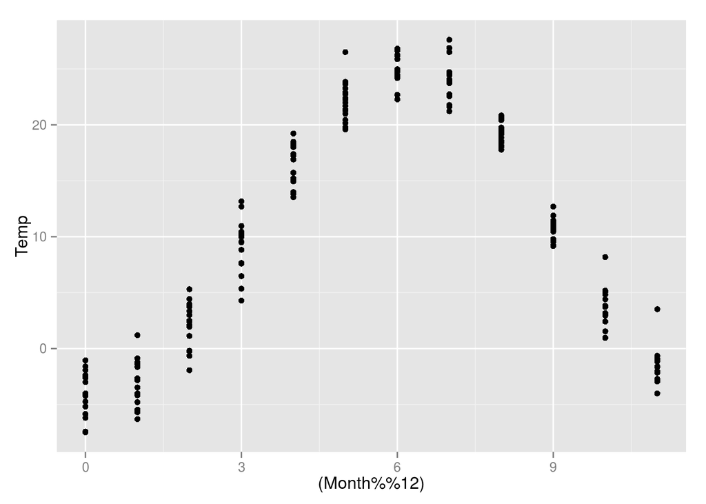

```r
ggplot(aes(x=(Month%%12),y=Temp),data=Mitchell)+
  geom_point()
```

### Understanding Noise: Age to Age Months

Notes:

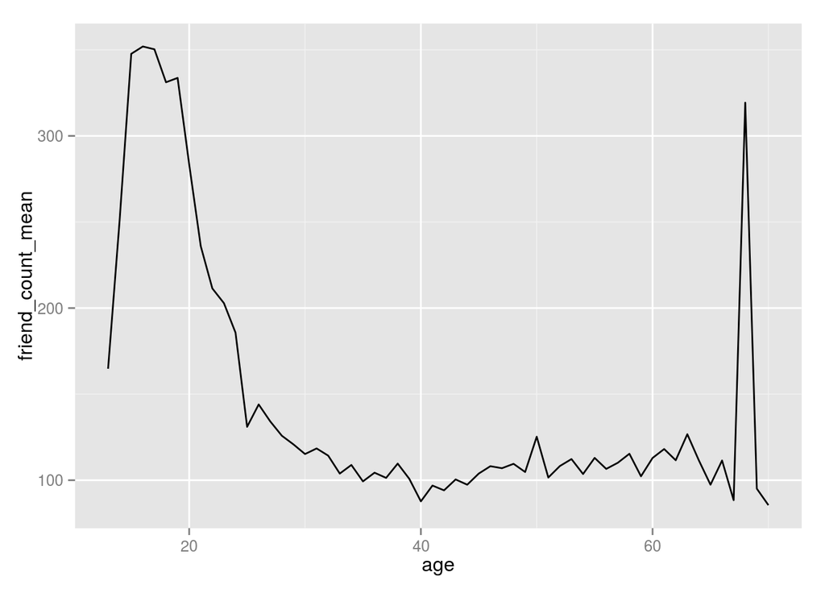

```r
ggplot(aes(x=age, y=friend_count_mean), data = subset(pf.fc_by_age, age < 71)) +
  geom_line()
```

### Age with Months Means

```r
pf$age_with_months = pf$age + (12 - pf$dob_month) / 12

pf.fc_by_age_months = pf %>%
  group_by(age_with_months) %>%
  summarise(friend_count_mean = mean(friend_count),
            friend_count_median = median(friend_count),
            n = n())

head(pf.fc_by_age_months)
```

```
## Source: local data frame [6 x 4]
##
##   age_with_months friend_count_mean friend_count_median  n
## 1        13.16667          46.33333                30.5  6
## 2        13.25000         115.07143                23.5 14
## 3        13.33333         136.20000                44.0 25
## 4        13.41667         164.24242                72.0 33
## 5        13.50000         131.17778                66.0 45
## 6        13.58333         156.81481                64.0 54
```

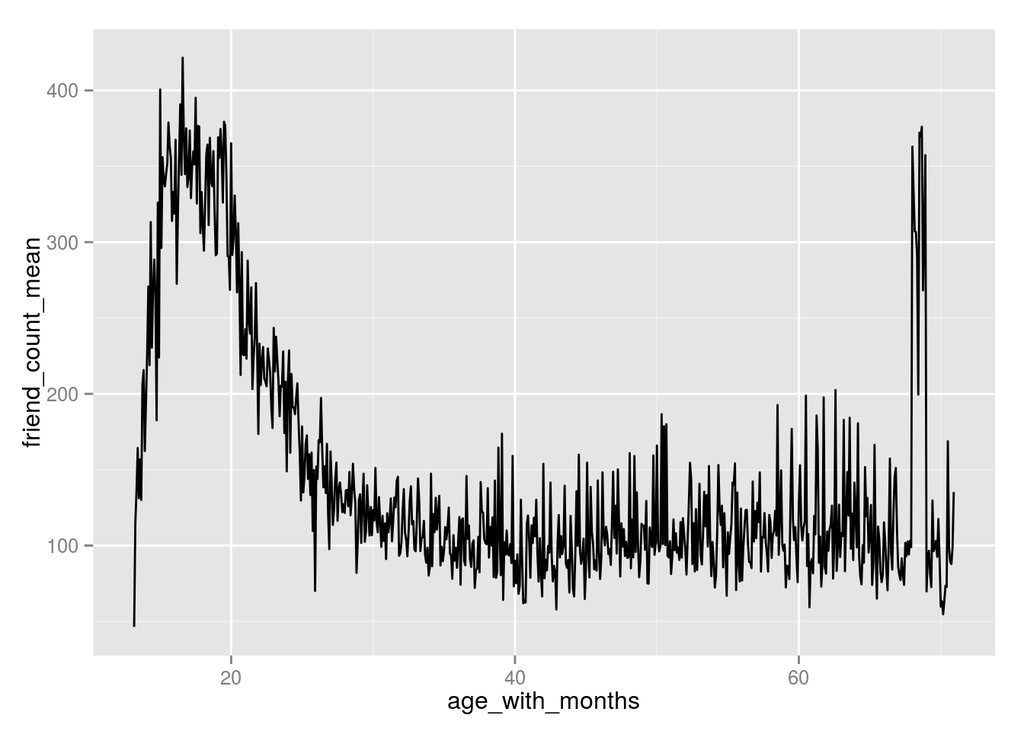

```r
ggplot(aes(x=age_with_months, y=friend_count_mean), data = subset(pf.fc_by_age_months, age_with_months < 71)) +
  geom_line()
```

### Smoothing Conditional Means

Notes: Smoothing can allow to see bigger trends in data, but it also obscures a lot of detail. This is an example of the bias/variance tradeoff.

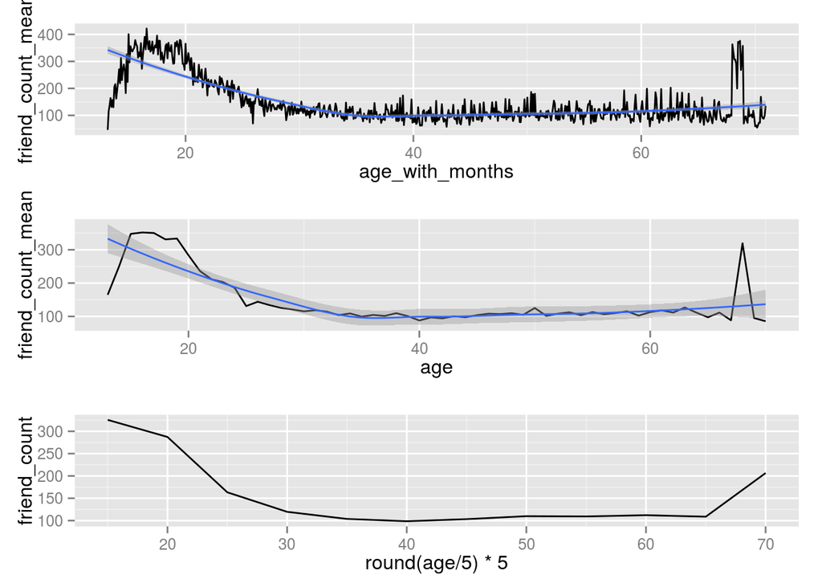

```r
p1 = ggplot(aes(x=age, y=friend_count_mean), data = subset(pf.fc_by_age, age < 71)) +
  geom_line() +
  geom_smooth()

p2 = ggplot(aes(x=age_with_months, y=friend_count_mean), data = subset(pf.fc_by_age_months, age_with_months < 71)) +
  geom_line() +
  geom_smooth()

p3 = ggplot(aes(x = round(age/5) * 5, y = friend_count),
            data = subset(pf, age < 71)) +
  geom_line(stat = 'summary', fun.y=mean)

library(gridExtra)
grid.arrange(p2, p1, p3, ncol= 1)
```

This project explores analysis of two variables and makes heavy use of scatterplots.

For more on bivariate analysis see these [notes](http://dept.stat.lsa.umich.edu/~kshedden/Courses/Stat401/Notes/401-bivariate-slides.pdf). ***